# Forecasting-Brazils-Freshwater-Resources-with-Predictive-Modeling

#### Model #1

```r
# Fit Dynamic Regression with ARIMA Errors
# Response: Renewable Freshwater Resources
# Predictor: Cattle Numbers
fit_ren_fresh <- ttsibble_data %>%
  model(ARIMA(Renewable.internal.freshwater.resources..cubic.meters ~
              Cattle...00000866....Stocks...005111....animals))

# Display model summary
report(fit_ren_fresh)
```

```
## Series: Renewable.internal.freshwater.resources..cubic.meters
## Model: LM w/ ARIMA(0,0,0) errors
##
## Coefficients:
##       Cattle...00000866....Stocks...005111....animals  intercept
##                                                 0e+00      4e-04
## s.e.                                            2e-04      2e-04
##
## sigma^2 estimated as 1.164e-10:  log likelihood=311.6
## AIC=-617.2   AICc=-616.31   BIC=-612.89
```

James modeled the time series “Renewable.internal.freshwater.resources..cubic.meters” using an ARIMA model with an external regressor, specifically the variable “Cattle…00000866….Stocks…005111….animals.” The ARIMA component was automatically selected as ARIMA(0,0,0)

James, then, proceeded to evaluate the residuals as follows to provide insights into the model’s performance.

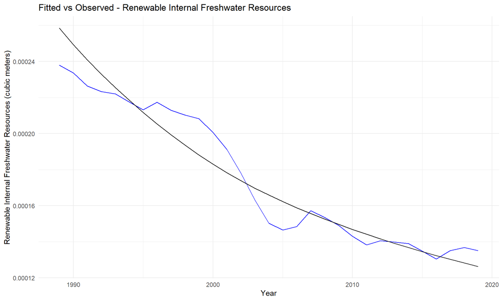

```r
# Fitted vs Observed Plot
fit_ren_fresh %>%
  augment() %>%
  autoplot(.fitted, color = 'blue') +
  autolayer(ttsibble_data, Renewable.internal.freshwater.resources..cubic.meters) +
  ggtitle("Fitted vs Observed - Renewable Internal Freshwater Resources") +
  xlab("Year") +
  ylab("Renewable Internal Freshwater Resources (cubic meters)") +
  theme_minimal()
```

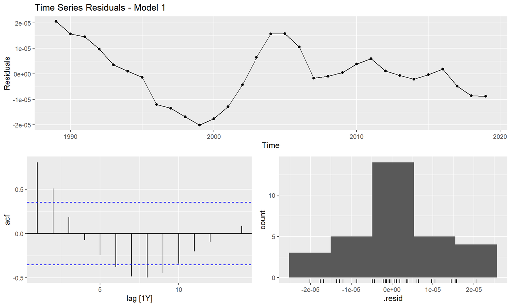

```r
# Residual Diagnostics
fit_ren_fresh %>%
  gg_tsresiduals() +
  labs(title = "Time Series Residuals - Model 1",
       x = "Time",
       y = "Residuals")
```

```r
# Ljung-Box Test for residual autocorrelation
ljung_box_results <- augment(fit_ren_fresh) %>%
  features(.innov, ljung_box, lag = 14)

knitr::kable(ljung_box_results,
             caption = "Ljung-Box Test Results",
             digits = 4)
```

Ljung-Box Test Results

| .model | lb_stat | lb_pvalue |
| --- | --- | --- |
| ARIMA(Renewable.internal.freshwater.resources..cubic.meters ~ |  |  |
| Cattle…00000866….Stocks…005111….animals) | 79.8606 | 0 |

James proceeded to evaluate the residuals to assess the model’s performance.

Findings:

Overall Assessment: The model demonstrates inadequate performance in capturing the relationship between cattle numbers and renewable freshwater resources. The significant residual autocorrelation (Ljung-Box p-value = 0) and clear patterns in the residuals plot indicate that important dynamics remain unmodeled. This suggests that:

1. The simple linear relationship with cattle may be insufficient
2. Additional predictors or non-linear transformations may be needed
3. A more complex ARIMA structure might be required to capture the temporal dynamics

Despite these limitations, James proceeds with the forecast to provide initial insights, while noting that Model 2 (incorporating freshwater withdrawals) may offer improved performance.